# Red Wine Analysis by Riyazudeen Abdul Subhan

# Introduction

I have dataset about Redwines and I am planning to explore the data and going to find out the intresting and hidden facts about red wine :). Wine is one of the most common and popular drinks among the people so let’s explore our data sample to find more about it.

Let’s see the strucute of the data

```
## 'data.frame':    1599 obs. of  13 variables:
##  $ X                   : int  1 2 3 4 5 6 7 8 9 10 ...
##  $ fixed.acidity       : num  7.4 7.8 7.8 11.2 7.4 7.4 7.9 7.3 7.8 7.5 ...
##  $ volatile.acidity    : num  0.7 0.88 0.76 0.28 0.7 0.66 0.6 0.65 0.58 0.5 ...
##  $ citric.acid         : num  0 0 0.04 0.56 0 0 0.06 0 0.02 0.36 ...
##  $ residual.sugar      : num  1.9 2.6 2.3 1.9 1.9 1.8 1.6 1.2 2 6.1 ...
##  $ chlorides           : num  0.076 0.098 0.092 0.075 0.076 0.075 0.069 0.065 0.073 0.071 ...
##  $ free.sulfur.dioxide : num  11 25 15 17 11 13 15 15 9 17 ...
##  $ total.sulfur.dioxide: num  34 67 54 60 34 40 59 21 18 102 ...
##  $ density             : num  0.998 0.997 0.997 0.998 0.998 ...
##  $ pH                  : num  3.51 3.2 3.26 3.16 3.51 3.51 3.3 3.39 3.36 3.35 ...
##  $ sulphates           : num  0.56 0.68 0.65 0.58 0.56 0.56 0.46 0.47 0.57 0.8 ...
##  $ alcohol             : num  9.4 9.8 9.8 9.8 9.4 9.4 9.4 10 9.5 10.5 ...
##  $ quality             : int  5 5 5 6 5 5 5 7 7 5 ...
```

```
##        X          fixed.acidity   volatile.acidity  citric.acid
##  Min.   :   1.0   Min.   : 4.60   Min.   :0.1200   Min.   :0.000
##  1st Qu.: 400.5   1st Qu.: 7.10   1st Qu.:0.3900   1st Qu.:0.090
##  Median : 800.0   Median : 7.90   Median :0.5200   Median :0.260
##  Mean   : 800.0   Mean   : 8.32   Mean   :0.5278   Mean   :0.271
##  3rd Qu.:1199.5   3rd Qu.: 9.20   3rd Qu.:0.6400   3rd Qu.:0.420
##  Max.   :1599.0   Max.   :15.90   Max.   :1.5800   Max.   :1.000
##  residual.sugar     chlorides       free.sulfur.dioxide
##  Min.   : 0.900   Min.   :0.01200   Min.   : 1.00
##  1st Qu.: 1.900   1st Qu.:0.07000   1st Qu.: 7.00
##  Median : 2.200   Median :0.07900   Median :14.00
##  Mean   : 2.539   Mean   :0.08747   Mean   :15.87
##  3rd Qu.: 2.600   3rd Qu.:0.09000   3rd Qu.:21.00
##  Max.   :15.500   Max.   :0.61100   Max.   :72.00
##  total.sulfur.dioxide    density             pH          sulphates
##  Min.   :  6.00       Min.   :0.9901   Min.   :2.740   Min.   :0.3300
##  1st Qu.: 22.00       1st Qu.:0.9956   1st Qu.:3.210   1st Qu.:0.5500
##  Median : 38.00       Median :0.9968   Median :3.310   Median :0.6200
##  Mean   : 46.47       Mean   :0.9967   Mean   :3.311   Mean   :0.6581
##  3rd Qu.: 62.00       3rd Qu.:0.9978   3rd Qu.:3.400   3rd Qu.:0.7300
##  Max.   :289.00       Max.   :1.0037   Max.   :4.010   Max.   :2.0000
##     alcohol         quality
##  Min.   : 8.40   Min.   :3.000
##  1st Qu.: 9.50   1st Qu.:5.000
##  Median :10.20   Median :6.000
##  Mean   :10.42   Mean   :5.636
##  3rd Qu.:11.10   3rd Qu.:6.000
##  Max.   :14.90   Max.   :8.000
```

# Univariate Plots Section

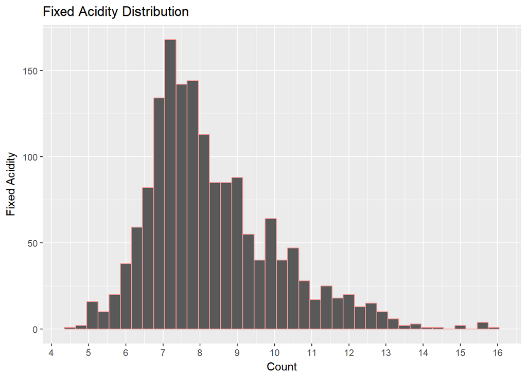

```
##    Min. 1st Qu.  Median    Mean 3rd Qu.    Max.
##    4.60    7.10    7.90    8.32    9.20   15.90
```

I have noticed that most of wine have a fixed acidity between 5 and 12.

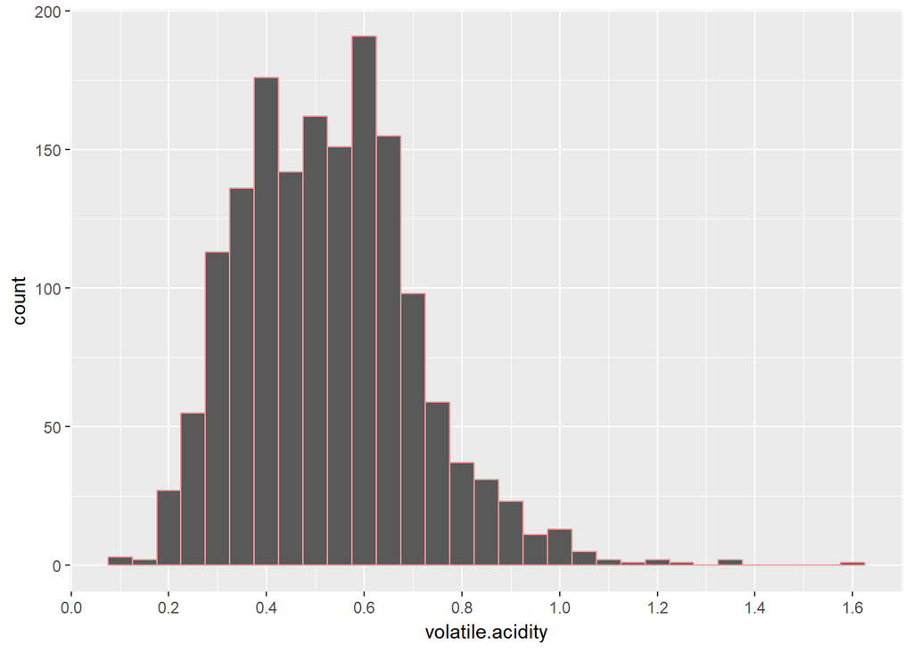

```
##    Min. 1st Qu.  Median    Mean 3rd Qu.    Max.
##  0.1200  0.3900  0.5200  0.5278  0.6400  1.5800
```

The wine with the lowest volatile acidity has a score of 0.12 and the highest has 1.58

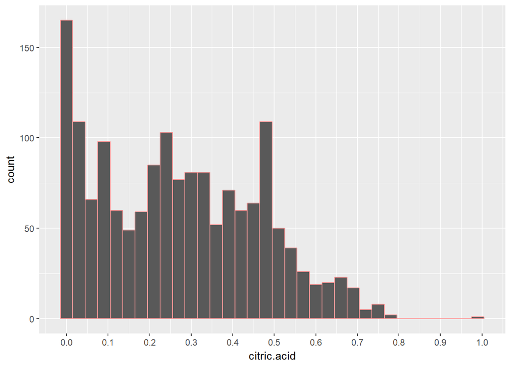

```
##    Min. 1st Qu.  Median    Mean 3rd Qu.    Max.
##   0.000   0.090   0.260   0.271   0.420   1.000
```

Most values lie between 0.09 and 0.42. The wine with the citric acid level of 1 is the only outlier in this distribution.

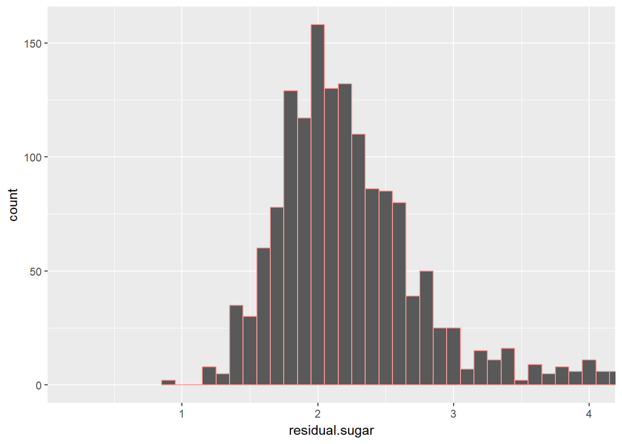

```
##    Min. 1st Qu.  Median    Mean 3rd Qu.    Max.
##   0.900   1.900   2.200   2.539   2.600  15.500
```

Most wines have a residual sugar level value between 1.9 and 2.6. The wine with the lowest residual sugar has a value of 0.9 and the highest has a score of 15.5

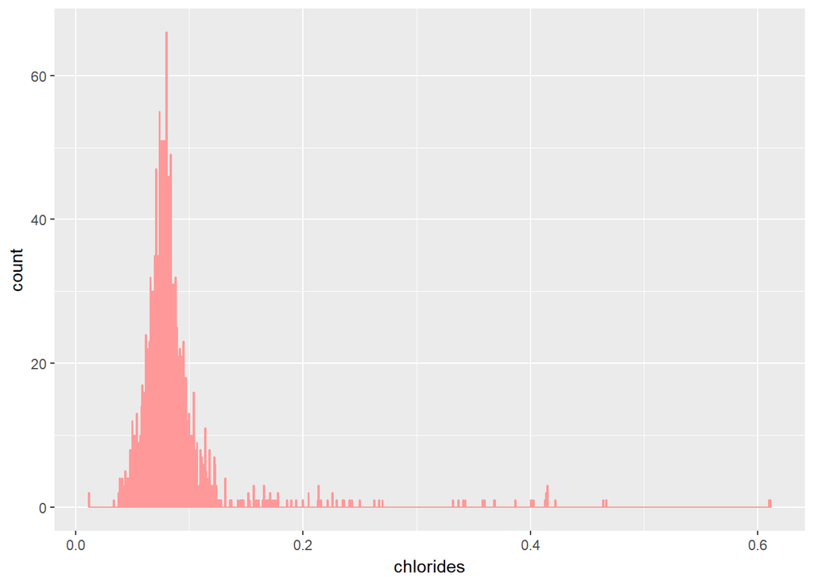

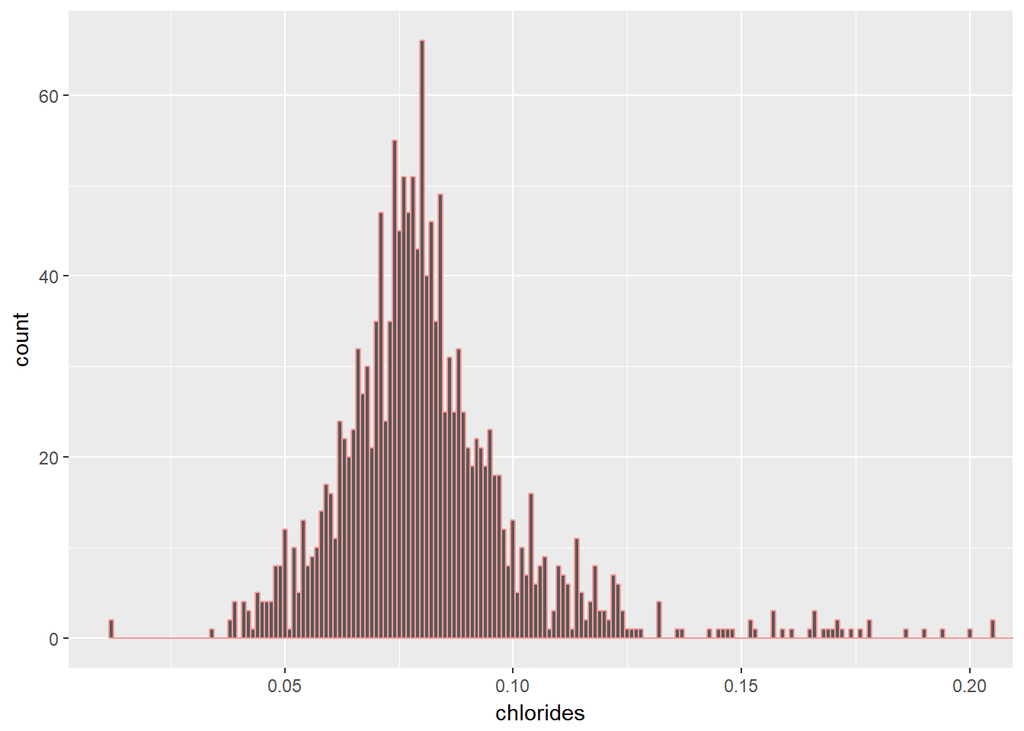

```
##    Min. 1st Qu.  Median    Mean 3rd Qu.    Max.
## 0.01200 0.07000 0.07900 0.08747 0.09000 0.61100
```

The chloride levels for the wines in the dataset range from 0.012 to 0.611. Most values lie between 0.07 and 0.09. There are multiple outliers in this distribution where the wines have chloride levels higher than 0.13.

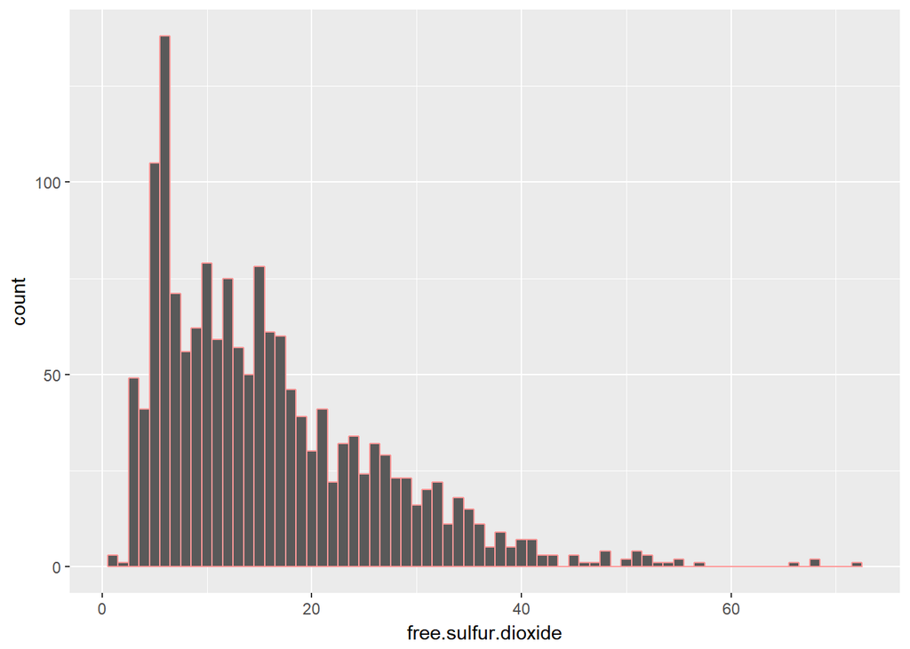

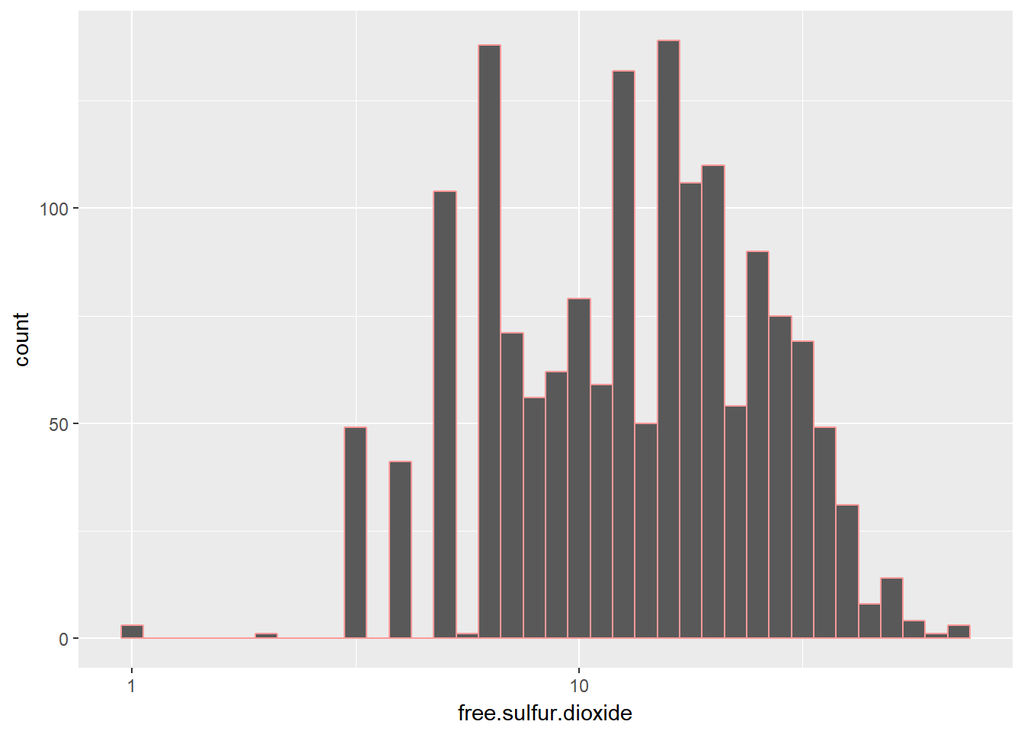

```
##    Min. 1st Qu.  Median    Mean 3rd Qu.    Max.
##    1.00    7.00   14.00   15.87   21.00   72.00
```

Most wines have values between 7 and 21. The lowest value is 1 and the highest is 72. There are multiple outliers in this distribution where the wines have free sulfur dioxide levels higher than 42.

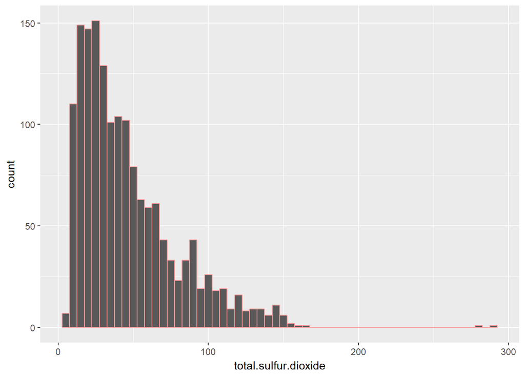

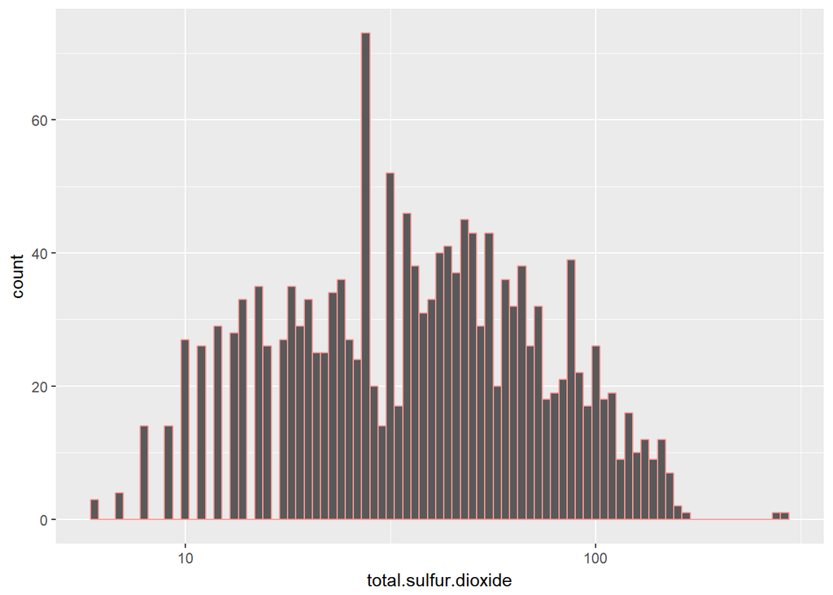

```
##    Min. 1st Qu.  Median    Mean 3rd Qu.    Max.
##    6.00   22.00   38.00   46.47   62.00  289.00
```

Total sulfur dioxide levels range between 6 and 289. Most values lie between 22 and 62.

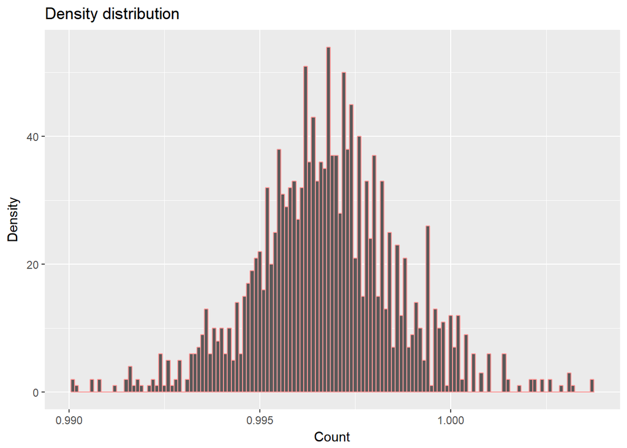

```
##    Min. 1st Qu.  Median    Mean 3rd Qu.    Max.
##  0.9901  0.9956  0.9968  0.9967  0.9978  1.0037
```

The density of the wine’s in the dataset range from 0.9901 to 1.004. Most wines lie between 0.9956 and 0.9978.

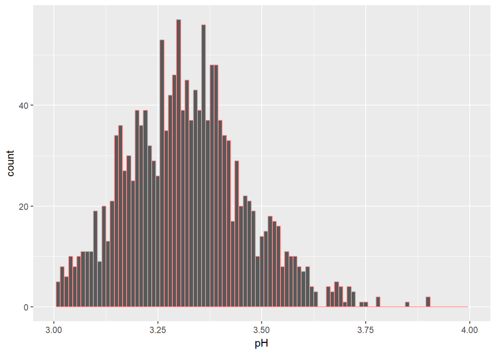

```
##    Min. 1st Qu.  Median    Mean 3rd Qu.    Max.
##   2.740   3.210   3.310   3.311   3.400   4.010
```

The pH levels of wine range from 2.74 to 4.01. Most have values between 3.21 and 3.4. There are multiple outliers in this distribution where the wines have pH levels that are either higher than 3.6.

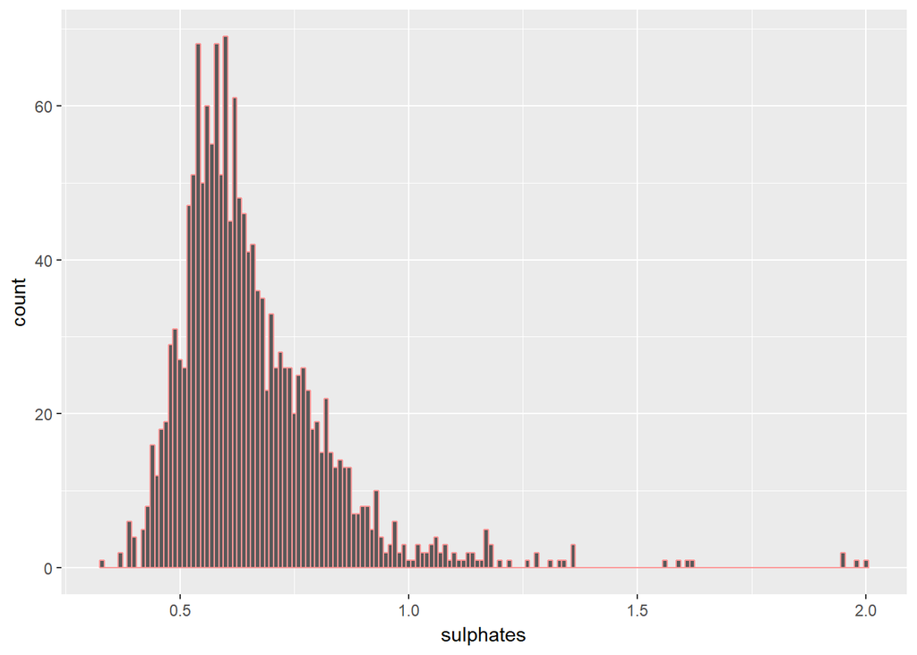

```
##    Min. 1st Qu.  Median    Mean 3rd Qu.    Max.
##  0.3300  0.5500  0.6200  0.6581  0.7300  2.0000
```

Sulphate levels range from 0.33 to 2.00. Most values lie between 0.55 and 0.73.

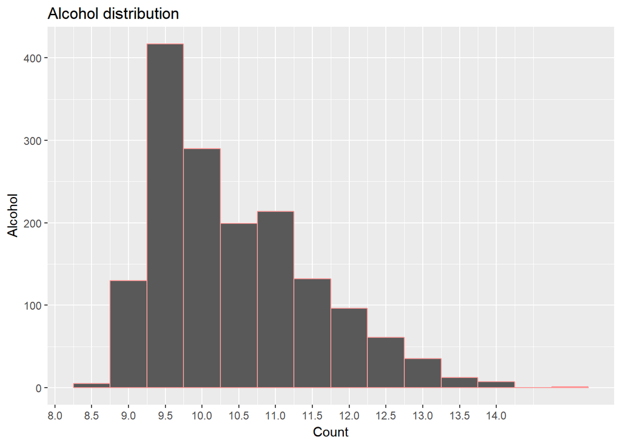

```
##    Min. 1st Qu.  Median    Mean 3rd Qu.    Max.
##    8.40    9.50   10.20   10.42   11.10   14.90
```

Most wines have alcohol levels between 9.5 and 11.1. The minimum is 8.4 and the maximum value is 14.9.

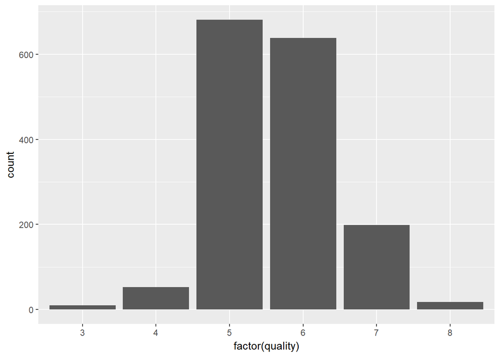

```
##    Min. 1st Qu.  Median    Mean 3rd Qu.    Max.
##   3.000   5.000   6.000   5.636   6.000   8.000
```

The quality ratings of wine range from 3 to 8. Most wines having a rating of 5 or 6.

# Univariate Analysis

### What is the structure of your dataset?

The dataset contains 1599 types of wines each with 11 independent variables that are based on physicochemical tests and one dependent variable. The dependent variable is the measurement of quality which is based on sensory data provided by wine experts. Quality variable has maximum value of 8 and min value 3 and there is no wine sample in the dataset which has quality of less than 3 and greater than 8. 2

### What is/are the main feature(s) of interest in your dataset?

The univariate analysis of the red wine dataset revealed interesting distributions in alcohol, fixed acidity, and sulphates. Each of these variables has long tails which I will investigate further in my bi-variate analysis. I suspect that these variables have an influence on the quality of the wine.

### Did you create any new variables from existing variables in the dataset?

Yes, I have created a new variable called ‘binary.quality’ to determine if wine is good or bad. Wines that have a quality rating of 6 or higher are deemed good. Any wine with a rating less than 6 is considered bad. Creating these two groups will help to uncover patterns from a bi-variate and multivariate analysis.

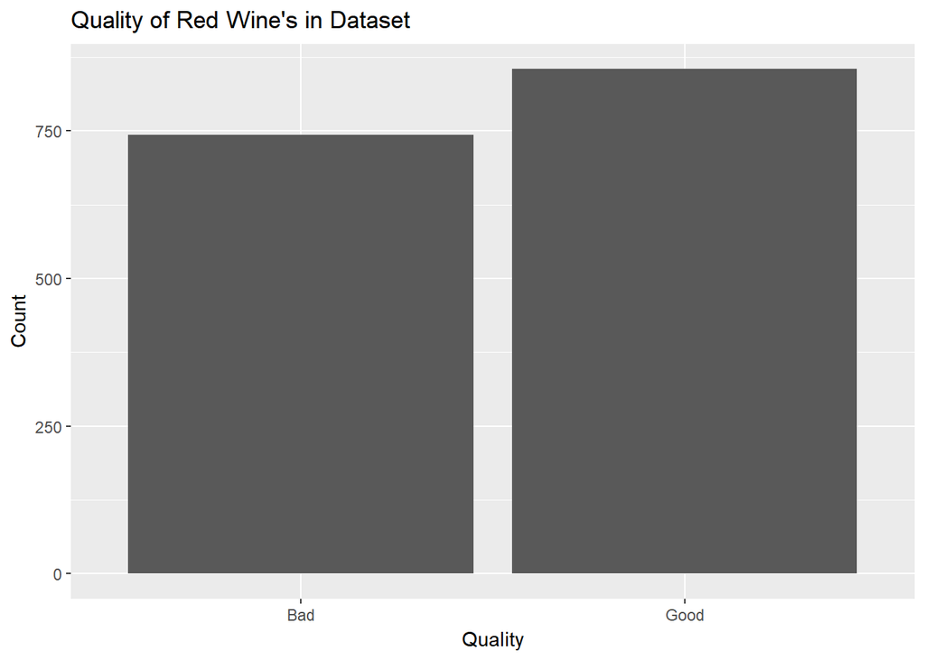

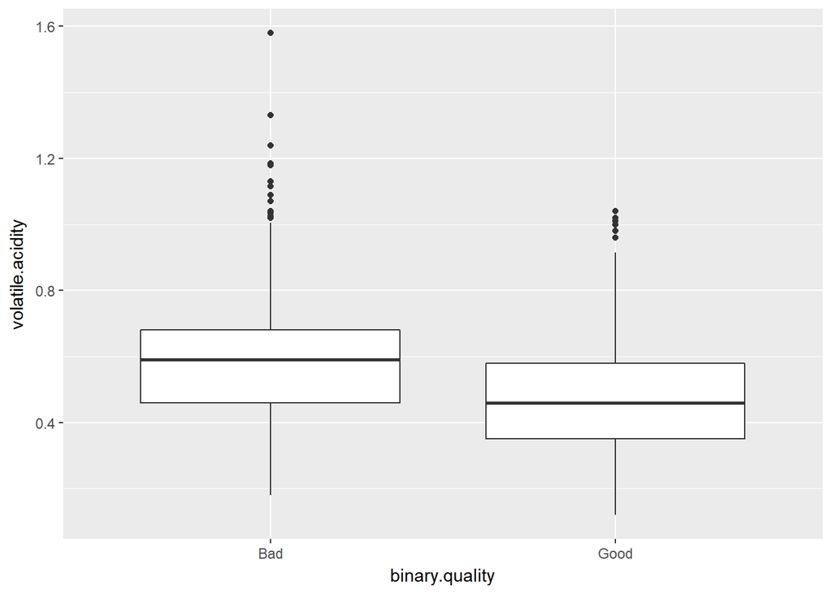

### Of the features you investigated, were there any unusual distributions?

In volatile acidity, it appears to be a bi modal distribution. There are multiple outliers in this distribution where the wines have volatile acidities higher than 1.015. No, I have not performed any data adjustment.

# Bivariate Plots Section

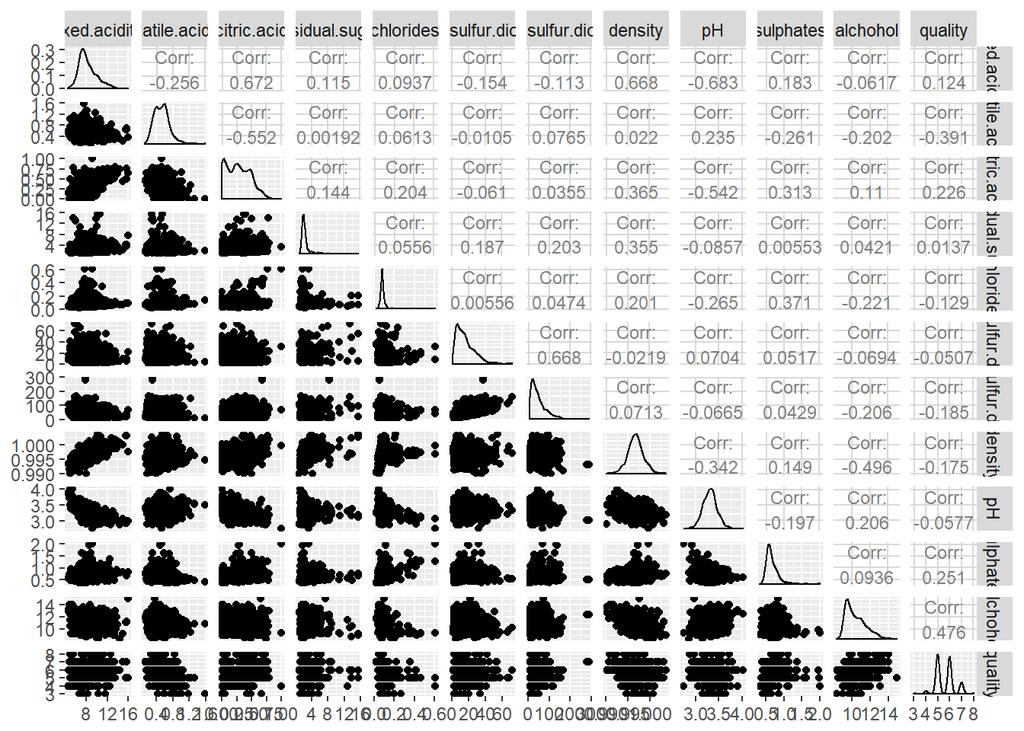

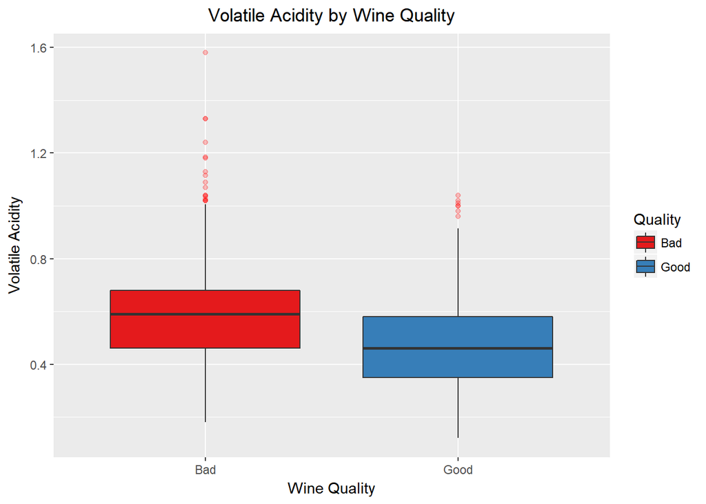

```
## pd$binary.quality: Bad
##    Min. 1st Qu.  Median    Mean 3rd Qu.    Max.
##  0.1800  0.4600  0.5900  0.5895  0.6800  1.5800
## --------------------------------------------------------
## pd$binary.quality: Good
##    Min. 1st Qu.  Median    Mean 3rd Qu.    Max.
##  0.1200  0.3500  0.4600  0.4741  0.5800  1.0400
```

The boxplot above shows that the variance for volatile acidity in good and bad wines is similar. Bad wines have a higher mean and median. The mean and median volatile acidity for good wines was 0.4741 and 0.46 respectively. The mean and median volatile acidity for bad wines was 0.5895 and 0.59 respectively.

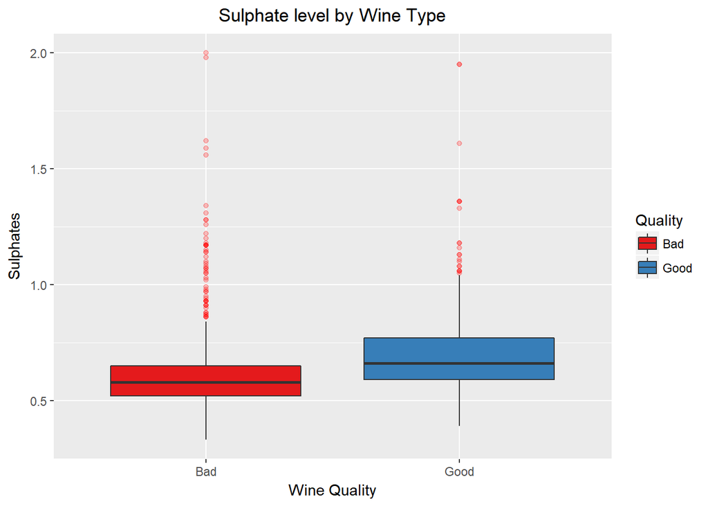

```
## pd$binary.quality: Bad
##    Min. 1st Qu.  Median    Mean 3rd Qu.    Max.
##  0.3300  0.5200  0.5800  0.6185  0.6500  2.0000
## --------------------------------------------------------
## pd$binary.quality: Good
##    Min. 1st Qu.  Median    Mean 3rd Qu.    Max.
##  0.3900  0.5900  0.6600  0.6926  0.7700  1.9500
```

Sulphate levels also vary between wines of different qualities. Good quality wines had higher mean and median sulphate levels. The mean and median values for good wines were 0.6926 and 0.66 respectively. Wines of poor quality had mean and median sulphate levels of 0.6185 and 0.58 respectively.

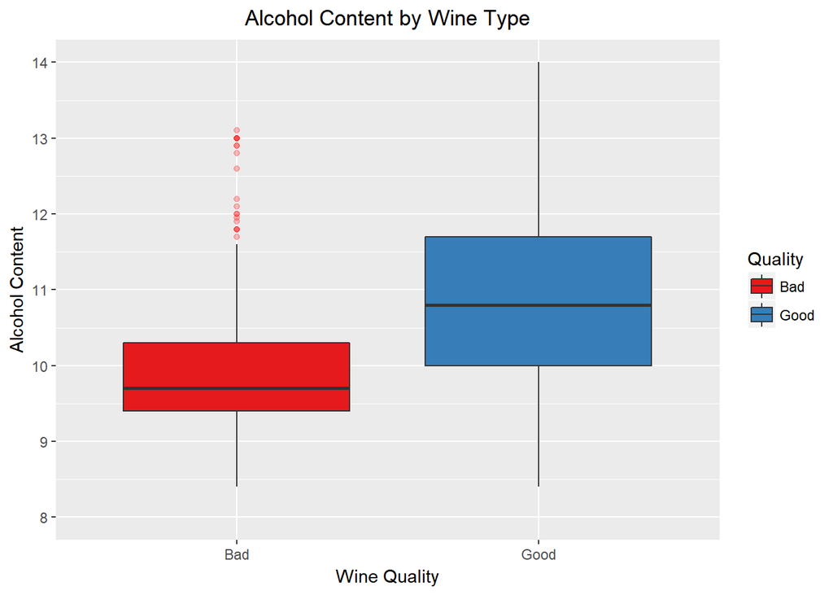

```
## pd$binary.quality: Bad
##    Min. 1st Qu.  Median    Mean 3rd Qu.    Max.
##   8.400   9.400   9.700   9.926  10.300  14.900
## --------------------------------------------------------
## pd$binary.quality: Good
##    Min. 1st Qu.  Median    Mean 3rd Qu.    Max.
##    8.40   10.00   10.80   10.86   11.70   14.00
```

Alcohol content varies depending on the quality of the wine. Wines of good quality have a higher variance as well as a higher mean and median. The mean and median alcohol content for good wines was 10.86 and 10.8 respectively. Bad wines had a mean alcohol content of 9.926 and a median of 9.7.

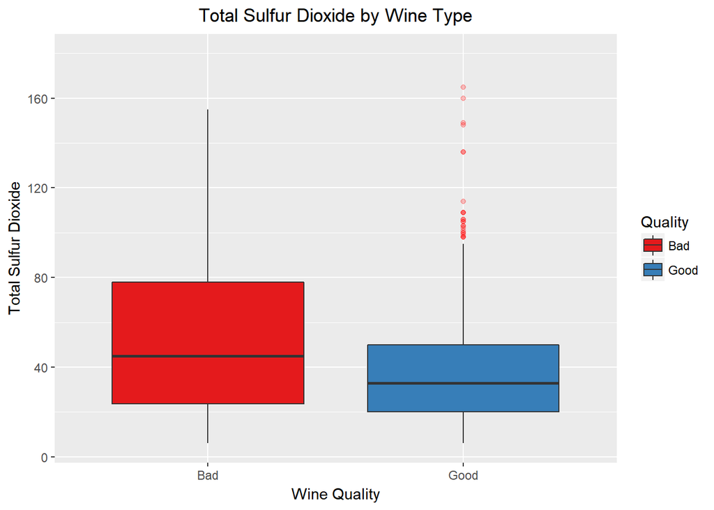

```
## pd$binary.quality: Bad
##    Min. 1st Qu.  Median    Mean 3rd Qu.    Max.
##    6.00   23.75   45.00   54.65   78.00  155.00
## --------------------------------------------------------
## pd$binary.quality: Good
##    Min. 1st Qu.  Median    Mean 3rd Qu.    Max.
##    6.00   20.00   33.00   39.35   50.00  289.00
```

Wines of poor quality have a larger variance in total sulfur dioxide levels as well as a higher mean and median. Wines of bad quality have a median of 45 and a mean of 54.65. Wines of good quality have a mean of 39.35 and a median of 33.

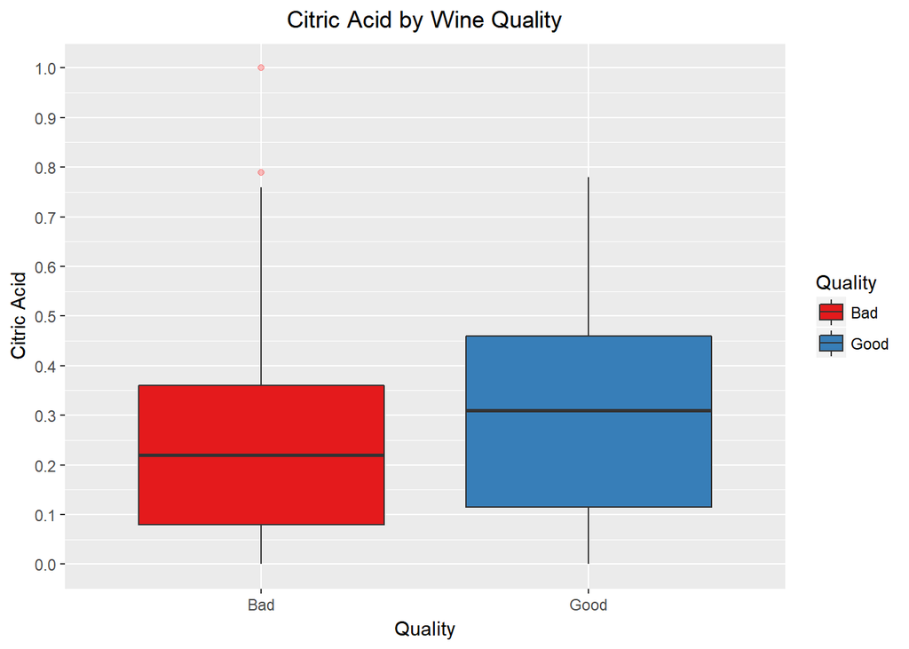

```
## pd$binary.quality: Bad
##    Min. 1st Qu.  Median    Mean 3rd Qu.    Max.
##  0.0000  0.0800  0.2200  0.2378  0.3600  1.0000
## --------------------------------------------------------
## pd$binary.quality: Good
##    Min. 1st Qu.  Median    Mean 3rd Qu.    Max.
##  0.0000  0.1150  0.3100  0.2999  0.4600  0.7800
```

# Bivariate Analysis

### Talk about some of the relationships you observed in this part of the

## investigation. How did the feature(s) of interest vary with other features in

the dataset?

[figure not shown]

```
## [1] -0.06166827
```

A bi-variate analysis of the dataset reveals that good wines have tend to have a higher alcohol content as well as lower levels of volatile acidity. These two variables do not seem to have a significant correlation with each other, but I will explore this relationship in more detail in my multivariate analysis.

### Did you observe any interesting relationships between the other features

### (not the main feature(s) of interest)?

One interesting relationship that wasn’t a main feature of interest, is that of fixed acidity and density. These two variables seem to have a significant correlation. This will be explored further.

### What was the strongest relationship you found?

```
## [1] -0.6829782
```

Fixed acidity and pH have the strongest correlation among all the variables analyzed in this dataset. The correlation coefficient for these two variables is -0.6829782. This would make sense because the pH scale is a measure of how basic or acidic a substance is. One would expect a high correlation for these two variables.

# Multivariate Plots Section

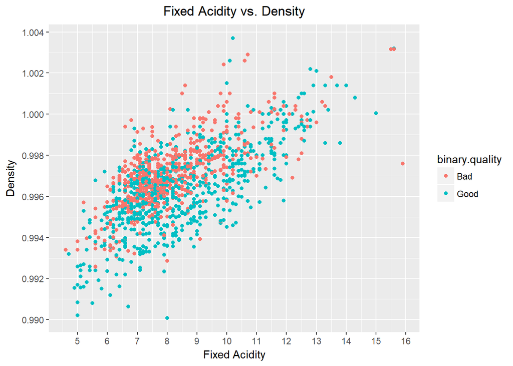

```
## [1] 0.6680473
```

In the previous section, I noted that density and fixed acidity seem to have a significant correlation. I examined this relationship further by creating a scatter plot of the two variables and labeling each point based on the quality of the underlying wine. It seems like at lower fixed acidity levels, good wines tend to have lower densities.

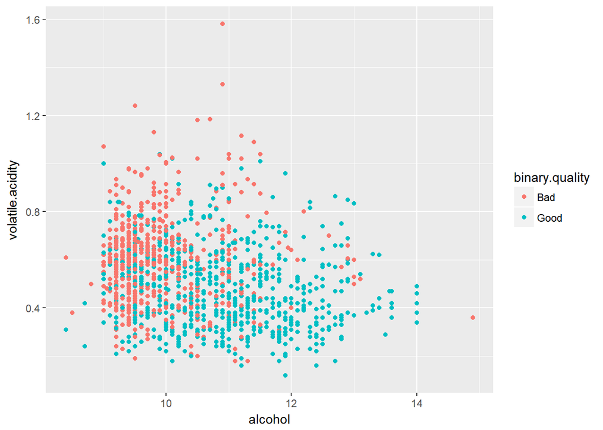

It seems like the higher the alcohol content and lower the volatile acidity of a wine, the more likely it is to be of good quality.

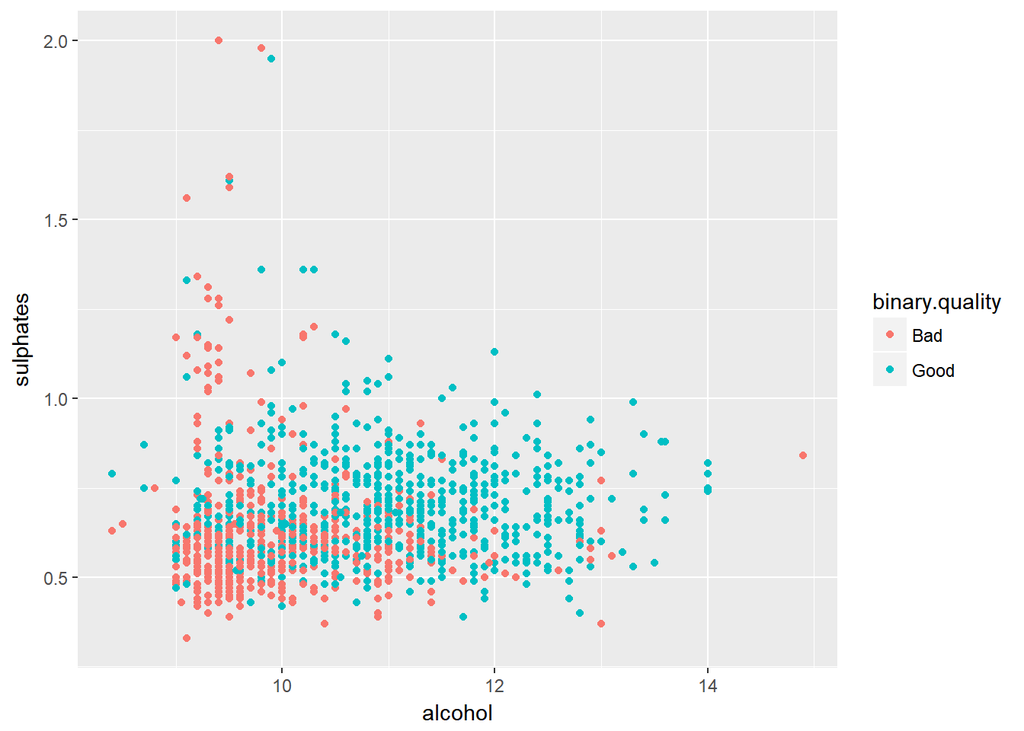

Higher sulphate levels and alcohol content also seem to be indicators of a good wine.

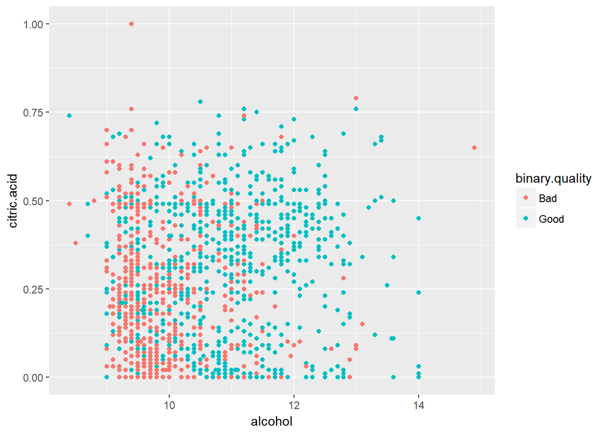

Similarly, wines with higher alcohol and citric acid levels tend to be of good quality.

# Multivariate Analysis

# Final Plots and Summary

### Plot One

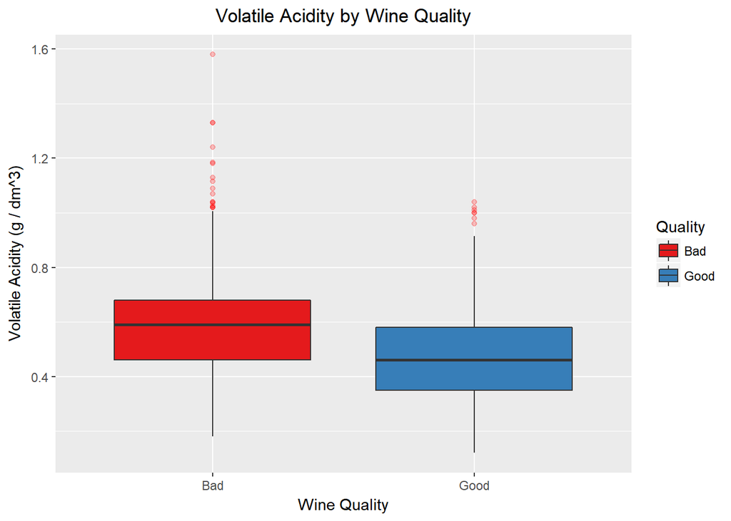

Most wines with a volatile acidity less than 0.6 tend to be of good quality. Wines with a volatile acidity higher than 0.6 were more likely to be of bad quality

### Alcohol Content and Wine Quality

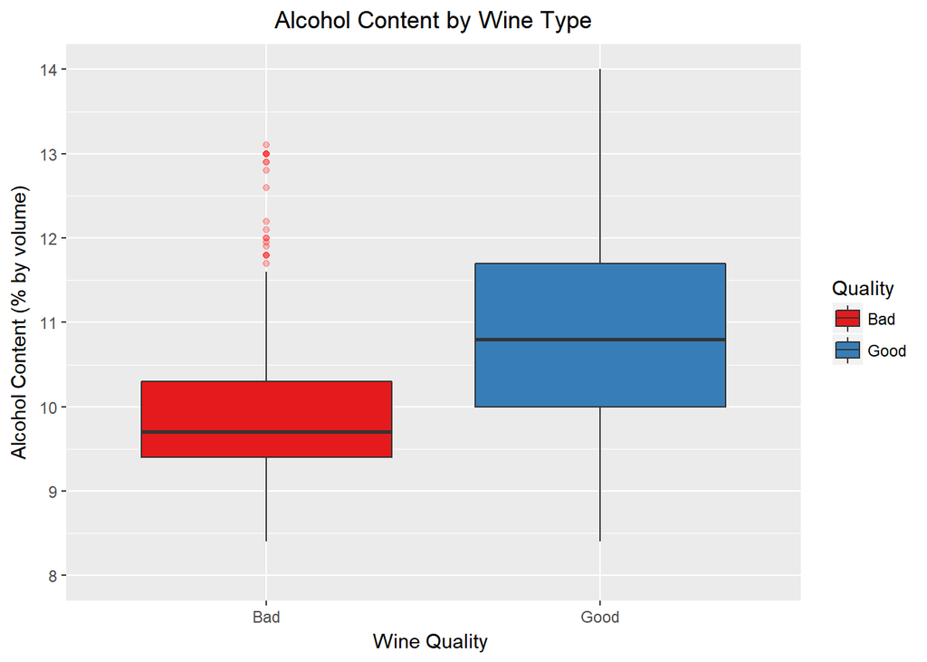

Most wines with an alcohol content greater than 10% are of good quality. There are significantly more wines with alcohol contents between 9 and 10% that are of bad quality.

### Plot Three

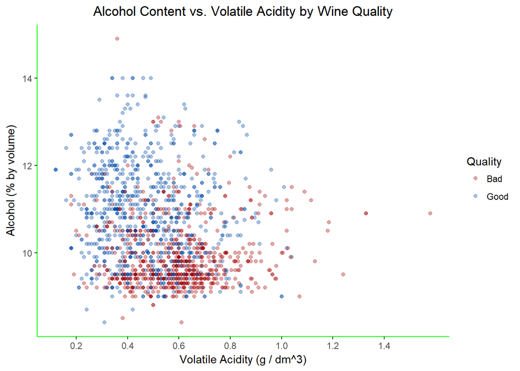

Wines with higher alcohol contents and lower volatile acidity levels were more likely to be of good quality. Most wines with alcohol contents greater than 10% and volatile acidity levels lower than 0.6 (g / dm^3) are of good quality.

# Reflection

Exploring the wine dataset revealed a relationship between the volatile acidity, alcohol content, and quality of a wine. Prior to conducting a bi-variate and multivariate analysis, the wines were divide into two groups(good/bad). Encoding the wines with a binary variable helped to discern which features had the most influence over the quality of wines. The higher the alcohol content of a wine, the more likely it is of good quality. Good quality wines also have lower volatile acidity levels.

Initially when I was developing for this project, I noticed that some wines didn’t have citric acid at all. My first thought was maybe this was bad data or incomplete data. But then I researched further about wines. I saw that citric acid actually is added to some wines to increase the acidity.So it’s evident that some wines would not have Citric Acid at all. So actually this was in parallel to my experimental findings.

For future analysis, I would love to have a dataset, where apart from the wine quality, a rank is given for that particular wine by 5 different wine tasters as we know when we include the human element, our opinion changes on so many different factors. So by including the human element in my analysis, I would be able to put in that perspective and see a lot of unseen factors which might result in a better or worse wine quality. Having these factors included inside the dataset would result in a different insight altogether in my analysis.